# Netflix Ratings

H MacGinty

June 2023

### Abstract

Netflix has seen a decline in users in recent months and a sharp decline in their share price. This peice investigates what works and what does not work for a future streaming service.

# Introduction

Netflix has experienced a drop in users. Using their data, I assess trends to ensure success in a future streaming program. The top actors and their frequency in titles, run time for popular titles, and most popular categories are examined.

# Netflix Statistics

Netflix is known for having terrible options for viewers. The new streaming service should keep the movies and show with the highest IMDB scores and drop those with the lowest.

It is important to have well reknowned actors on Netflix in order to keep viewers interested.

Actors are arranged by their average IMDb score and filtered to only include those with the top IMDb scores. From this, we can find the 17 actors with the highest IMDb scores - thus reflecting actors of the best calibre. The frequency of these top 17 actors in Netflix titles are presented in the following table.

Some of the top actors, like Anna Gunn and Betsy Brandt, only appear in one Netflix title. To maintain customers, streaming services should increase the number of titles that feature these 17 actors. Customers will not give up on their Netflix accounts if they feel Netflix can maintain prestige and present the best actors and titles.

Table 1: Top Actors on Netflix by IMDB Score and their Frequency in Netflix titles

|  | Actor | Frequency |
| --- | --- | --- |
| 1 | André Sogliuzzo | 2 |
| 2 | Anna Gunn | 1 |
| 3 | Betsy Brandt | 1 |
| 4 | Bob Odenkirk | 5 |
| 5 | Bryan Cranston | 9 |
| 6 | Cricket Leigh | 1 |
| 7 | David Attenborough | 5 |
| 8 | Dean Norris | 11 |
| 9 | Dee Bradley Baker | 13 |
| 10 | Greg Baldwin | 4 |
| 11 | Grey DeLisle | 14 |
| 12 | Jack De Sena | 2 |
| 13 | Jessie Flower | 1 |
| 14 | Jonathan Banks | 8 |
| 15 | Mae Whitman | 3 |
| 16 | Mayur More | 3 |
| 17 | Zach Tyler | 1 |

By averaging popularity (from TMDb score) by genre, it can be seen that Sci-fi is the most popular genre, followed by horror. To keep viewers interested, it is worth increasing the number of movies and shows in these categories to ensure customers are not lost. Since documentaries and reality, on average, have low popularity, it is worth considering cutting down on these genres which are plentiful on Netflix.

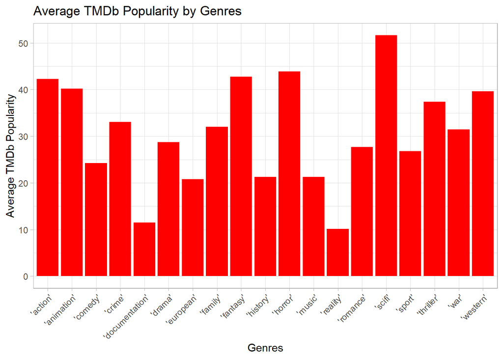

By filtering the data to include the most popular movies, based on the TMDb popularity score of above 100, it is shown that the most popular movies typically have a run time around 100 minutes. The streaming serivce should thus aim to have movie runtimes that are approximately this long. Movies shorter or substantially longer tend to be less popular.

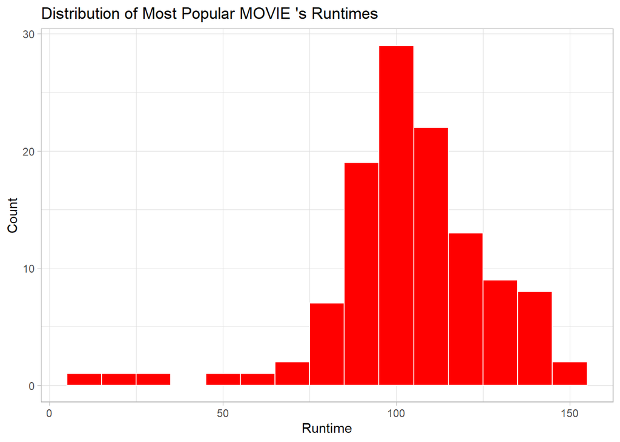

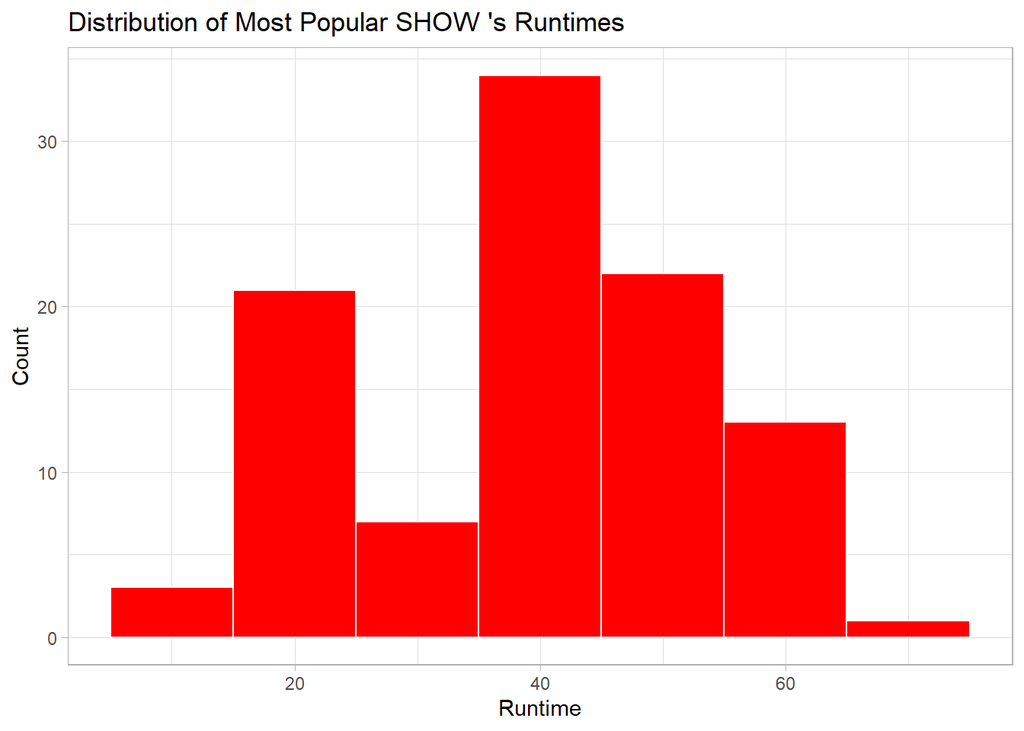

# Conclusion

Overall, there are a number of steps Netflix can take to address its decline in viewers. It should include more movies and shows with the best actors according to IMDb scores, include more shows with the most popular genres, such as Sci-fi, and ensure that series and movies are the appropriate and optimal length to keep viewers interested.